# HW_1

Dmitrii Belousov

2024-11-17

# Инструкции

Ниже приведены семь клинических (исследовательских) гипотез. В качестве задания протестируйте их, используя соответствующие статистические критерии. Решение должно содержать все элементы алгоритма проверки статистических гипотез:

• Сформулируете нулевую и альтернативную гипотезы. • Укажите уровень значимости α. • Определите статистический тест (критерий) для проверки гипотезы. При необходимости аргументируйте выбор одностороннего теста. • Укажите критическое значение статистики (используйте распределения из материалов лекции). • Определите наблюдаемое значение статистики. • Оцените статистическую значимость (p-value и/или доверительный интервал). • Оцените практическую значимость.

- Решение необходимо загружать в формате Rmd (воспроизводимый код). ** Данные для анализа необходимо генерировать самостоятельно в соответствии с каждой представленной гипотезой. По возможности используйте пакет dplyr *** Предусмотрен мягкий дедлайн (17 ноября). В этом случае вы получите комментарии с возможностью повысить оценку. Сдача работы после жёсткого дедлайна (24 ноября) предусматривает снижение оценки (10 баллов).

# Гипотеза 1. Существует ассоциация между уровнем физической активности (бинарная переменная, физическая активность может быть ‘высокой’ и ‘низкой’) и частотой возникновения сердечно-сосудистых заболеваний у пациентов старше 50 лет. Попробуйте вариант с большими выборками (sample_size <- 100). Как изменится стратегия при малых выборках (sample_size <- 30) ?

## Генерация данных

```r
# Воспроизводимость результатов
set.seed(42)

# Общий размер выборки
sample_size <- 100

# Генерация данных по физической активности (бинарная переменная) в фиксированном соотношении 1:1
activity <- rbinom(sample_size, size = 1, prob = 0.5)

# Генерация данных по наличию сердечно-сосудистых заболеваний (бинарная переменная)
# У активных людей меньше вероятность заболеть (0.5 vs 0.6)

cardio <- rbinom(sample_size, size = 1, prob = ifelse(activity == 1, 0.5, 0.6))

table(activity, cardio)
```

```
##         cardio
## activity  0  1
##        0 19 26
##        1 21 34
```

$Н_0$: $p_{ССЗ\;в\;гр.\;акт.} = p_{ССЗ\;в\;гр.\;неакт.}$, $Н_{альт}$: $p_{ССЗ\;в\;гр.\;акт.} \neq p_{ССЗ\;в\;гр.\;неакт.}$. Зададим уровень значимости $\alpha = 0.05$. Большая выборка позволяет использовать ассимптотические тесты, поэтому для тестирования гипотезы в этой выборке мы используем тест хи-квадрат. Критическое значение статистики для односторонней гипотезы:

```r
alpha <- 0.05
chi_critical <- qchisq(1 - alpha, df = 1)
chi_critical
```

```
## [1] 3.841459
```

```r
chisq.test(table(activity, cardio))
```

```
##
##  Pearson's Chi-squared test with Yates' continuity correction
##
## data:  table(activity, cardio)
## X-squared = 0.042088, df = 1, p-value = 0.8375
```

Результат свидетельствует о статистически и практически не значимой ассоциации.

```r
# Воспроизводимость результатов
set.seed(42)

# Общий размер выборки
sample_size <- 30

# Генерация данных по физической активности (бинарная переменная) в фиксированном соотношении 1:1
activity <- rbinom(sample_size, size = 1, prob = 0.5)

# Генерация данных по наличию сердечно-сосудистых заболеваний (бинарная переменная)
# У активных людей меньше вероятность заболеть (0.5 vs 0.6)

cardio <- rbinom(sample_size, size = 1, prob = ifelse(activity == 1, 0.5, 0.6))

table(activity, cardio)
```

```
##         cardio
## activity  0  1
##        0  4  7
##        1  7 12
```

```r
fisher.test(table(activity, cardio))
```

```
##
##  Fisher's Exact Test for Count Data
##
## data:  table(activity, cardio)
## p-value = 1
## alternative hypothesis: true odds ratio is not equal to 1
## 95 percent confidence interval:
##  0.1523513 5.7610691
## sample estimates:
## odds ratio
##   0.980262
```

```r
chisq.test(table(activity, cardio), simulate.p.value = T, B = 1000)
```

```
##
##  Pearson's Chi-squared test with simulated p-value (based on 1000
##  replicates)
##
## data:  table(activity, cardio)
## X-squared = 0.0006868, df = NA, p-value = 1
```

Для малой выборки лучше использовать точный тест Фишера или тест хи-квадрат Пирсона с симулированными р-значениями методом Монте-Карло. Тем не менее, результаты все равно не значимы.

# Гипотеза 2. Применение нового метода лечения для пациентов с артериальной гипертензией приведет к уменьшению среднего артериального давления по сравнению с пациентами, получающими стандартное лечение.

## Генерация данных

```r
# Воспроизводимость результатов
set.seed(42)

# Размер выборки (в каждой группе)
sample_size <- 80


# В популяции c экспериментальным методом лечения средний уровень систолического артериального давления меньше (130 vs 135 mm)
# Генерация данных для группы с новым методом лечения
group1 <- rnorm(n = sample_size, mean = 130, sd = 10)  # экспериментальная группа

# Генерация данных для группы со стандартным лечением
group2 <- rnorm(n = sample_size, mean = 135, sd = 10)  # контрольная группа
```

$Н_0$: $\mu_1 = \mu_2$, $Н_{альт}$: $\mu_1 \neq \mu_2$. Зададим уровень значимости $\alpha = 0.05$. Используем для проверки этой гипотезы Т-тест Стьюдента.

```r
alpha = 0.05
df = sample_size * 2 - 2
upper = qt(p = 1 - alpha / 2, df = df)
lower = qt(p = alpha / 2, df = df)

sprintf("Критические значения статистики: [%.2f, %.2f]", lower, upper)
```

```
## [1] "Критические значения статистики: [-1.98, 1.98]"
```

## Решение

```r
t.test(group1, group2, var.equal = T)
```

```
##
##  Two Sample t-test
##
## data:  group1 and group2
## t = -2.3719, df = 158, p-value = 0.0189
## alternative hypothesis: true difference in means is not equal to 0
## 95 percent confidence interval:
##  -6.8739564 -0.6274236
## sample estimates:
## mean of x mean of y
##  130.2015  133.9522
```

Статистически, различия значимы, р-значение меньше выбранного порога значимости. Клинически, я предполагаю, что тоже, так как лечение позволило уменьшить давление до показателей близких к верхней границе нормы. Хочу отметить, что результат теста мог быть разным в зависимости от того, какую дисперсию я бы выбрал для симуляции выборки.

# Гипотеза 3. Внедрение программы реабилитации для пациентов с хронической болью в спине приведет к улучшению их физической активности (предположим что физическую активность можно оценить по шкале 0-100)

## Генерация данных

```r
# Воспроизводимость результатов
set.seed(42)

# Размер выборки
sample_size <- 30

# В популяции до реабилитации средний уровень физической активности меньше (50 vs 60)
# Генерация данных до реабилитации
before <- rbinom(n = sample_size, size = 100, prob = 0.5)

# Генерация данных после реабилитации
after <- rbinom(n = sample_size, size = 100, prob = 0.6)
```

$Н_0$: $p(X_{before} > X_{after}) = p(X_{after} > X_{before})$, $Н_{альт}$: $p(X_{before} > X_{after}) \neq p(X_{after} > X_{before})$. Зададим уровень значимости $\alpha = 0.05$. Используем для проверки этой гипотезы тест Вилкоксона для зависимых выборок.

```r
alpha = 0.05
upper = qsignrank(1 - alpha/2, n = sample_size, lower.tail = F)
lower = qsignrank(alpha/2, n = sample_size, lower.tail = F)

sprintf("Критические значения статистики: [%.2f, %.2f]", lower, upper)
```

```
## [1] "Критические значения статистики: [327.00, 138.00]"
```

## Решение

```r
wilcox.test(before, after, exact = FALSE, paired = T)
```

```
##
##  Wilcoxon signed rank test with continuity correction
##
## data:  before and after
## V = 18.5, p-value = 1.115e-05
## alternative hypothesis: true location shift is not equal to 0
```

Мы получили статистически значимые различия, однако клиническая значимость результата под вопросом, потому что шкала вымышленная.

# Гипотеза 4. Применение нового метода лечения для пациентов с инфарктом миокарда увеличит долю вернувшихся к нормальной физической активности

## Генерация данных

```r
# Воспроизводимость результатов
set.seed(42)

# Общий размер выборки
sample_size <- 200


# В популяции экспериментального лечения вероятность нормальной физической активности больше (0.7 vs 0.65)
# Генерация данных по статусу лечение (бинарная переменная, новый метод или стандарт) в фиксированном соотношении 1:1
treatment <- rbinom(sample_size, size = 1, prob = 0.5)

# Генерация данных по физической активности после лечения (бинарная переменная)
activity <- rbinom(sample_size, size = 1, prob = ifelse(treatment == 1, 0.7, 0.65))

table(treatment, activity)
```

```
##          activity
## treatment  0  1
##         0 27 62
##         1 29 82
```

$Н_0$: $p_{норм.физ.акт\;в\;гр.\;плацебо} = p_{норм.физ.акт\;в\;гр.\;лечения}$, $Н_{альт}$: $p_{норм.физ.акт\;в\;гр.\;плацебо} \neq p_{норм.физ.акт\;в\;гр.\;лечения}$. Зададим уровень значимости $\alpha = 0.05$. Большая выборка позволяет использовать ассимптотические тесты, поэтому для тестирования гипотезы в этой выборке мы используем тест хи-квадрат. Критическое значение статистики:

```r
alpha <- 0.05
chi_critical <- qchisq(1 - alpha, df = 1)
chi_critical
```

```
## [1] 3.841459
```

## Решение

```r
chisq.test(table(treatment, activity))
```

```
##
##  Pearson's Chi-squared test with Yates' continuity correction
##
## data:  table(treatment, activity)
## X-squared = 0.25069, df = 1, p-value = 0.6166
```

Результат свидетельствует о статистически и практически не значимой ассоциации.

# Гипотеза 5. Применение медитации в течение 8 недель повлияет на наличие стресса (есть/нет) у лиц с высоким уровнем тревожности.

## Генерация данных

```r
# Воспроизводимость результатов
set.seed(42)

# Размер выборки
sample_size <- 50

# Генерация данных до медитации (бинарная переменная) в фиксированном соотношении 1:1
before <- rbinom(sample_size, size = 1, prob = 0.5)

# Генерация данных после медитации (бинарная переменная).
# После медитации вероятность наличия стресса меньше (0.2 vs 0.4)
after <- rbinom(sample_size, size = 1, prob = ifelse(before == 1, 0.2, 0.4))
table(before, after)
```

```
##       after
## before  0  1
##      0 12  7
##      1 29  2
```

$Н_0$: $p_{before} = p_{after}$, $Н_{альт}$: $p_{before} \neq p_{after}$. Зададим уровень значимости $\alpha = 0.05$. Большая выборка позволяет использовать ассимптотические тесты, наблюдения связаны, поэтому используем тест МакНемара. Критическое значение статистики для односторонней гипотезы:

```r
alpha <- 0.05
chi_critical <- qchisq(1 - alpha, df = 1)
chi_critical
```

```
## [1] 3.841459
```

## Решение

```r
mcnemar.exact(table(before, after))
```

```
##
##  Exact McNemar test (with central confidence intervals)
##
## data:  table(before, after)
## b = 7, c = 29, p-value = 0.0003126
## alternative hypothesis: true odds ratio is not equal to 1
## 95 percent confidence interval:
##  0.08925774 0.56310574
## sample estimates:
## odds ratio
##  0.2413793
```

Результат статистически и практически значим. Точный тест был использован так как он дает оценки доверительных интервалов.

# Гипотеза 6. Применение альтернативного метода лечения для пациентов с биполярным расстройством приведет к значимому изменению уровня симптомов депрессии по отношению к группе, прошедшей стандартное лечение (депрессию можно определить по шкале от 0 до 100, при этом исследователь должен избегать любых предположений (кроме i.i.d.)).

## Генерация данных

```r
# Воспроизводимость результатов
set.seed(42)

# Размер выборки для каждой группы
sample_size <- 20


# В популяции c экспериментальным методом лечения среднее депрессии меньше (55 vs 68)
# Генерация данных для экспериментальной группы
group1 <- rbinom(n = sample_size, size = 100, prob = 0.55)

# Генерация данных для группы со стандартным лечением
group2 <- rbinom(n = sample_size, size = 100, prob = 0.68)
```

$Н_0$: $p(X_{experimental} > X_{control}) = p(X_{experimental} > X_{control})$, $Н_{альт}$: $p(X_{experimental} > X_{control}) \neq p(X_{experimental} > X_{control})$. Зададим уровень значимости $\alpha = 0.05$. Используем для проверки этой гипотезы тест Манна-Уитни-Вилкоксона.

```r
alpha = 0.05
upper = qwilcox(1 - alpha/2, n = sample_size, m = sample_size, lower.tail = F)
lower = qwilcox(alpha/2, n = sample_size, m = sample_size, lower.tail = F)

sprintf("Критические значения статистики: [%.2f, %.2f]", lower, upper)
```

```
## [1] "Критические значения статистики: [272.00, 128.00]"
```

Применим асимптотический тест Манна-Уитни:

## Решение

```r
wilcox.test(group1,group2,conf.int=TRUE, exact = F)
```

```
##
##  Wilcoxon rank sum test with continuity correction
##
## data:  group1 and group2
## W = 9, p-value = 2.437e-07
## alternative hypothesis: true location shift is not equal to 0
## 95 percent confidence interval:
##  -15.999965  -9.999995
## sample estimates:
## difference in location
##              -12.99992
```

Результат статистически значим, практически, вероятно, тоже.

# Гипотеза 7. Длительность сна (в часах) ассоциирована с уровенем стресса у студентов (шкала с нормальным распределением)

## Генерация данных

```r
library(mvtnorm) # библиотека mvtnorm для работы с многомерным нормальным распределением

# Воспроизводимость результатов
set.seed(42)

# Размер выборки
sample_size <- 100

# Средние значения для длительности сна (HoursOfSleep) и уровня стресса (StressLevel) в популяции
means <- c(7, 5)

sigma_X <- 2
sigma_Y <- 3

# Матрица ковариации. В ислледуемой популяции HoursOfSleep и StressLevel ассоциированы отрицательно (r = -0.5)
cov_matrix <- matrix(c(sigma_X ** 2, -0.5 * sigma_X * sigma_Y, -0.5 * sigma_X * sigma_Y, sigma_Y ** 2), nrow = 2)

df <- rmvnorm(n = sample_size,
              mean = means,
              sigma = cov_matrix) %>%
      as_tibble() %>%
      setNames(c("HoursOfSleep", "StressLevel"))
```

$H_0$: $\rho = 0$, $H_{альт}$: $\rho \neq 0$. Для проверки гипотезы будем использовать критерий корреляции Пирсона. Рассчитаем критические значения t-статистики:

```r
alpha <- 0.05
upper <- qt(p = 1 - alpha/2, df = sample_size - 2)
lower <- qt(p =  alpha/2, df = sample_size - 2)
sprintf("Критические значения статистики: [%.2f, %.2f]", lower, upper)
```

```
## [1] "Критические значения статистики: [-1.98, 1.98]"
```

## Решение (дополните решение визуализацией)

```r
library(ggpubr)
res <- psych::corr.test(df$HoursOfSleep, df$StressLevel, method = "pearson")
print(res, short=FALSE)
```

```
## Call:psych::corr.test(x = df$HoursOfSleep, y = df$StressLevel, method = "pearson")
## Correlation matrix
## [1] -0.52
## Sample Size
## [1] 100
## These are the unadjusted probability values.
##   The probability values  adjusted for multiple tests are in the p.adj object.
## [1] 0
##
##  Confidence intervals based upon normal theory.  To get bootstrapped values, try cor.ci
##       raw.lower raw.r raw.upper raw.p lower.adj upper.adj
## NA-NA     -0.65 -0.52     -0.37     0     -0.65     -0.37
```

```r
t_obs <- (res$r * sqrt(sample_size)) / sqrt(1 - res$r ** 2)

sprintf("Наблюдаемое значение t-тсатистики: %.2f", t_obs)
```

```
## [1] "Наблюдаемое значение t-тсатистики: -6.16"
```

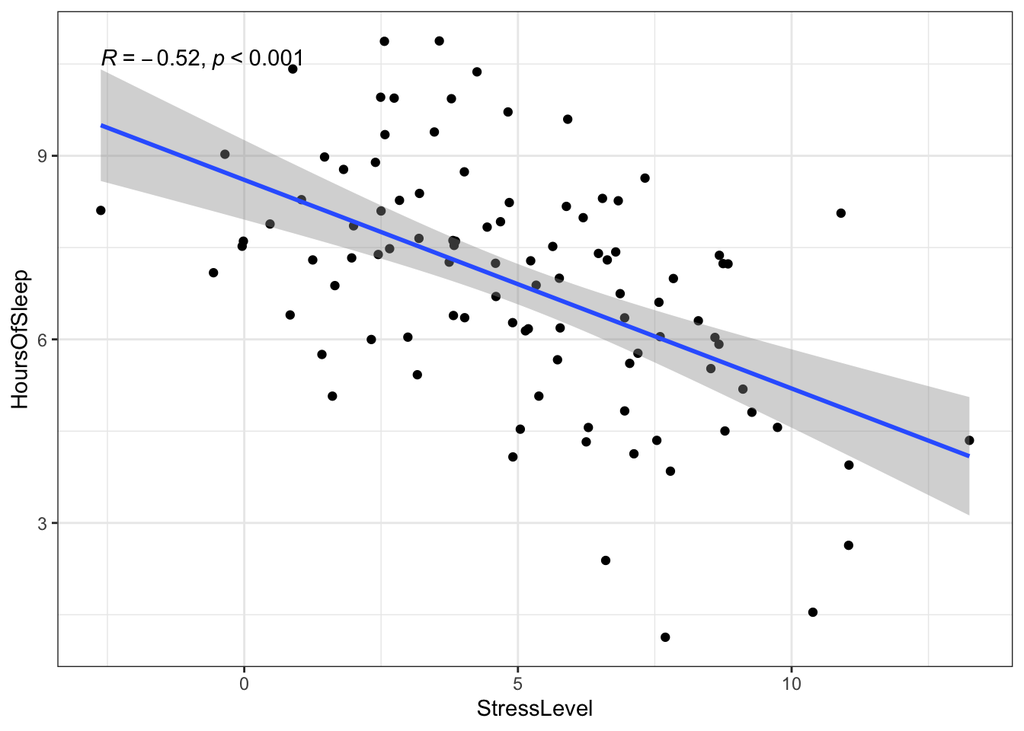

```r
df %>%
  ggplot(aes(y = HoursOfSleep, x = StressLevel)) +
  geom_point() +
  geom_smooth(method = "lm") +
  stat_cor(p.accuracy = 0.001, r.accuracy = 0.01) +
  theme_bw()
```

Результат статистически практически значим.